# Jordan Lake Reservoir Model

Part10: Future trends (with historical temperature)

Smitom Borah

01/05/2023

# 1 Motivation

In this notebook, we develop future trends of TP in water and sediment columns under the scenario if historical temperatures persisted in the future. The final visualization are done in subsequent parts.

# 2 Edit log

*No new edits since its creation.*

# 3 Loading packages

Following packages were used in this notebook.

```r
# Loading the packages----
if (!require("pacman")) install.packages("pacman") ;
pacman::p_load(shinyjs,threejs,xlsx,minpack.lm,MuMIn,lme4,penalized,zoo,RColorBrewer,gridExtra,rowr,stringi,optimx,purrrlyr,Hmisc,leaps,caret,magrittr,plotly,remotes,RcppRoll,suncalc,adaptMCMC,TTR, truncnorm, readxl,lubridate, data.table,deSolve,zoo,tidyverse)
```

```r
library(lubridate)

library(caret)
library(randomForest)
```

# 4 Functions

```r
# Functions----
## Function to determine the season of the year
Season <- function(Date){
  #--------
  # Argument detail:
  # Date : date vector
  #--------

  # Creating a month vector
  Mo <- month(Date)
  season <- rep(NA, length(Mo))
  for (i in 1:length(Mo)) {
    if (Mo[i] %in% c(1,2,3)){
      season[i] <- "Winter"
    } else if (Mo[i] %in% c(4,5,6)){
      season[i] <- "Spring"
    } else if (Mo[i] %in% c(7,8,9)){
      season[i] <- "Summer"
    } else {
      season[i] <- "Fall"
    }

  }
  return(season)
}
### test run
# Season(as.Date("2018-10-12", format = "%Y-%m-%d"))

## function to calculate 35days moving average of a column
MA35func <- function(x){
  #--------
  # Argument detail:
  # x : column whose 35d moving average needs to be calculated
  #--------

  return(rollmean(x, 35, fill = NA, align = "right"))

}

## function to calculate 14days moving average of a column
MA14func <- function(x){
  #--------
  # Argument detail:
  # x : column whose 14d moving average needs to be calculated
  #--------

  return(rollmean(x, 14, fill = NA, align = "right"))

}
```

# 5 General Plotting specification

To maintain the consistency in the plots developed in this notebook, we create a ggplot object to store the basic specification for each plot.

```r
# General plot specification
plot_basics <- ggplot()+
  theme_bw()+
  theme(legend.background = element_blank(),
        panel.grid.major = element_blank(),
        panel.grid.minor = element_blank(),
        legend.text.align = 0,
        text = element_text(size = 10),
        legend.text = element_text(size = 10, color = "black"),
        axis.title = element_text(size = 10, color = "black"),
        axis.text = element_text(size = 10, color = "black"))
```

# 6 Calibration and forecast period

```r
# Daily period of record and prediction----
## Daily period of record
date.cali.daily <- floor_date(seq(ymd('1983-01-01'),
                                  ymd('2018-12-31'),
                                  by = 'day'),
                        unit = "day")

## Period of prediction
date.pred.daily <- floor_date(seq(ymd('2019-01-01'),
                                  ymd('2090-12-31'),
                                  by = 'day'),
                        unit = "day")


# Monthly period of record and prediction----
## Period of record
date_cali <- floor_date(seq(ymd('1983-01-01'),ymd('2018-12-01'), by = 'month'), unit = "month")

## Period of prediction
date_scen <- floor_date(seq(ymd('2019-01-01'),ymd('2090-12-01'), by = 'month'), unit = "month")
```

# 7 Future Trends with historical temperature

## 7.1 Inputs

In this section, we specify the inputs required to run the model

```r
# Percentage reduction in external P loading
exPL00 <- -0

# Number of posterior parameter samples
N <- 1000

# Loading the First-order workspace
load("RWorkSpaces/JLPMv016p001_1.RData")

# Inputs
Popt_par <- opt_prm
PinpDF <- RoutMOdin[,!colnames(RoutMOdin) %in% c("...1")]
PinpDF <- RoutMOdin
Pinp <- RoutMOdin %>% creaInp(.,tlim=nrow(.))
Pico <- Const_lis
Pico$timestep <- 1:length(Pinp$A1t)
Pico$vs_scal <- vs_scal
Pico$par_scal <- par_scal

# Changing the Date of PinpDF
PinpDF$Date <- as.Date(paste0(PinpDF$mo,"/1/",PinpDF$year), format = "%m/%d/%Y")

# Adding the hypolimnion middepths
# loading the monthly hypolimnetic depths data
hypo.midDepth.raw <- read_excel("DataFiles/HypolimnionCalcs.xlsx",
                                sheet = "Sheet1", range = "A2:Y434")%>%
  rename(.,
         H1m = `H1 m...22`,
         H2m = `H2 m...23`,
         H3m = `H3 m...24`,
         H4m = `H4 m...25`)

# Only segments 2-4
hypo.midDepth <- hypo.midDepth.raw[,c("start_d", "H2m", "H3m", "H4m")]

# renaming a column
colnames(hypo.midDepth)[1] <- "Date"
hypo.midDepth$Date <- as.Date(hypo.midDepth$Date)

# Adding the hypolimnion mid-depths to PinpDF
PinpDF <- merge(PinpDF,hypo.midDepth,by = "Date", all.x = T )


# Setting seed
set.seed(500)
# sampling set of posterior samples
postPsmpl <- RAM$samples[sample(seq((nrow(RAM$samples)-25000),nrow(RAM$samples)), N, replace = F),]


# Separating the observations
Pobs <- obs %>% transmute(cale_date=myd(paste0(as.character(ym),"-1")),
                          TPugL = obs,variable)

# Check for segments
all_seg <- Pobs %>% pull(variable) %>% unique # should be 4 : "C1","C2","C3" and "C4"

# Loading the functions file
source("Pmodels/JLPMfunv16p005.R")

# Projection years
yrs_prj <- date_scen %>% year %>% unique %>% length()
```

# 8 Average Mass in the historical years

Let us calculate the average mass in each segment in the historical years. This information is useful for future year P concentration predictions.

```r
# average Mass in each segments
## Segment 1
meanM1 <- mean(MassFlows[which(MassFlows$year %in% c(1999,2018)),]$M1)

## Segment 2
meanM2 <- mean(MassFlows[which(MassFlows$year %in% c(1999,2018)),]$M2)

## Segment 3
meanM3 <- mean(MassFlows[which(MassFlows$year %in% c(1999,2018)),]$M3)

## Segment 4
meanM4 <- mean(MassFlows[which(MassFlows$year %in% c(1999,2018)),]$M4)

# Quick view
AvgMoP.df<- data.frame(Segment = c(1,2,3,4), Avg.P.Mass_kg_mo = c(meanM1, meanM2, meanM3, meanM4))
AvgMoP.df
```

| Segment | Avg.P.Mass_kg_mo |
| --- | --- |
| 1 | 1850.067 |
| 2 | 3736.194 |
| 3 | 5534.170 |
| 4 | 4302.757 |

# 9 Historical temperature projections

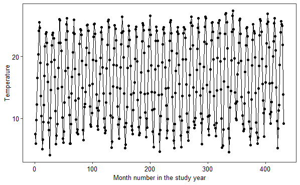

```r
# Plotting the bottom water temperature between 1999 and 2018
hist_temp <- RoutMOdin[,c("Date","Temperature")]

plot_basics+
  geom_point(data = hist_temp, aes(x = seq(1,432), y = Temperature))+
  geom_line(data = hist_temp, aes(x = seq(1,432), y = Temperature))+
  labs(x = "Month number in the study year",
       y = "Temperature")
```

## 9.1 Generating future projections

```r
# setting a timer
start_time <- Sys.time()

# A vector of historical years
set.seed(500)
Hyr <- sample(rep(seq(1999,2018), times =3 ), 60, replace = F)

# Number of historical years
nhist <- length(Hyr)

HistYears.df <- data.frame(y2019 = Hyr)

for (y in 1:(yrs_prj-1)) {
  Mod <- paste0("y",y+2019)
  Hyr <- c(Hyr[2:nhist],Hyr[1])
  HistYears.df <- cbind(HistYears.df,Hyr)
  colnames(HistYears.df)[ncol(HistYears.df)] <- Mod
}

HistYears.df <- HistYears.df%>%t%>% as.data.frame()

set.seed(456)
HistYears.df <- HistYears.df[sample(1:nrow(HistYears.df),nrow(HistYears.df),replace = FALSE ),]

# Turing the columns into a list of input future series
HistYears <- list()
for(i in 1:ncol(HistYears.df)) {             # Using for-loop to add columns to list
  HistYears[[i]] <- HistYears.df[[i]]
}

# Number of parameter sets to be considered for each year
npar <- 1000 # TODO change to 1000

# Sampling say 100 parameter sets from 1000 without replacement
set.seed(456)
parset <- sample(1:nrow(postPsmpl), npar, replace= FALSE)

# Creating a list to store all the dataframes
PparhydL00 <- list()
PallL00 <- list()

# number of times random error are added
rnum <- 1


for (i in 1:nhist){
  # i <- 1 #TODO remove this line in the final cleaned version

  ## Scenario selection
  EP_red <- exPL00

  ## Future years with one year data from the historical years
  PinpFut <- data.frame()
  for (ii in 1:yrs_prj){
    tdf <- PinpDF[which(PinpDF$year %in% HistYears[[i]][ii]),]
    tdf$Date <- as.Date(tdf$Date)
    tdf[1, !(colnames(tdf) %in% c("Date", "yrmo"))] <- as.numeric(tdf[1, !(colnames(tdf) %in% c("Date", "yrmo"))])

    PinpFut %<>%bind_rows(.,tdf)
  }

  # Correcting order of t
  PinpFut$t <- seq(1,nrow(PinpFut))

  # Getting the dates right
  PinpFut$Date <- as.Date(date_scen)


  # Combining calibration and prediction datasets together
  PinpDFall <- PinpDF %>% as_tibble() %>% bind_rows(.,PinpFut) %>%
    rowid_to_column(., "ro")

  # Accounting for imaginary volume addition/removal in future years
  PinpDF <- PinpVolBal.fun(PinpDFall1 = PinpDF)
  PinpFut <- PinpVolBal.fun(PinpDFall1 = PinpFut)
  PinpDFall <- PinpVolBal.fun()

  # Correcting the years
  PinpFut$year <- year(PinpFut$Date)
  PinpDFall$year <- year(PinpDFall$Date)

  # Bottom to surface P ratio
  ## Segment 2 bottom to surface P ratio
  Seg2_BoSuPmo <- Seg2_BoSuP %>% mutate(year = year(as.Date(Seg2_BoSuP$Date, format = "%Y-%m-%d")),
                                       month = month(as.Date(Seg2_BoSuP$Date, format = "%Y-%m-%d")))

  Seg2_BoSuPmo <- Seg2_BoSuPmo %>% group_by(year, month) %>%
    summarise(Rbs2 = median(pred_BoSuP))

  BotSurPrat2 <- data.frame()
  for (ii in 1:yrs_prj){
    tdf <- Seg2_BoSuPmo[which(Seg2_BoSuPmo$year %in% HistYears[[i]][ii]),]
    BotSurPrat2 %<>%bind_rows(.,tdf)
  }

  BotSurPrat2all <- Seg2_BoSuPmo %>% as_tibble() %>% bind_rows(., BotSurPrat2)
  Pico$Rbs2 <- BotSurPrat2all$Rbs2

  ## Segment 3 bottom to surface P ratio
  Seg3_BoSuPmo <- Seg3_BoSuP %>% mutate(year = year(as.Date(Seg3_BoSuP$Date, format = "%Y-%m-%d")),
                                       month = month(as.Date(Seg3_BoSuP$Date, format = "%Y-%m-%d")))

  Seg3_BoSuPmo <- Seg3_BoSuPmo %>% group_by(year, month) %>%
    summarise(Rbs3 = median(pred_BoSuP))

  BotSurPrat3 <- data.frame()
  for (ii in 1:yrs_prj){
    tdf <- Seg3_BoSuPmo[which(Seg3_BoSuPmo$year %in% HistYears[[i]][ii]),]
    BotSurPrat3 %<>%bind_rows(.,tdf)
  }

  BotSurPrat3all <- Seg3_BoSuPmo %>% as_tibble() %>% bind_rows(., BotSurPrat3)
  Pico$Rbs3 <- BotSurPrat3all$Rbs3

  ## Segment 4 bottom to surface P ratio
  Seg4_BoSuPmo <- Seg4_BoSuP %>% mutate(year = year(as.Date(Seg4_BoSuP$Date, format = "%Y-%m-%d")),
                                       month = month(as.Date(Seg4_BoSuP$Date, format = "%Y-%m-%d")))

  Seg4_BoSuPmo <- Seg4_BoSuPmo %>% group_by(year, month) %>%
    summarise(Rbs4 = median(pred_BoSuP))

  BotSurPrat4 <- data.frame()
  for (ii in 1:yrs_prj){
    tdf <- Seg4_BoSuPmo[which(Seg4_BoSuPmo$year %in% HistYears[[i]][ii]),]
    BotSurPrat4 %<>%bind_rows(.,tdf)
  }

  BotSurPrat4all <- Seg4_BoSuPmo %>% as_tibble() %>% bind_rows(., BotSurPrat4)
  Pico$Rbs4 <- BotSurPrat4all$Rbs4

  # Arranging the dataset
  PinpCaSc <- PinpDFall %>% creaInp(.,tlim=nrow(.))
  Pico$timestep <- 1:length(PinpCaSc$A1t)

  # temporary save
  Pico_tmp1 <- Pico
  Pico_tmp2 <- Pico

  # Model run for calibration part
  # Arranging the calibration dataset
  # PinpCaSc1 <- PinpDF %>% creaInp(.,tlim=nrow(.))
  PinpCaSc1 <- PinpDFall[1:(nrow(PinpDF)+1),] %>% creaInp(.,tlim=nrow(.))
  Pico_tmp1$timestep <- 1:length(PinpCaSc1$A1t)
  Pico_tmp1$Rbs2 <- Pico_tmp1$Rbs2[1:length(PinpCaSc1$A1t)]
  Pico_tmp1$Rbs3 <- Pico_tmp1$Rbs2[1:length(PinpCaSc1$A1t)]
  Pico_tmp1$Rbs4 <- Pico_tmp1$Rbs2[1:length(PinpCaSc1$A1t)]

    # Temporary objects to store model outputs
  ## object to store outputs w/ parameter + hydrologic uncertainty
  PparhydL00x <- list()
  PallL00x <- list()

  # Generating model outputs based on each historical year and
  # each different parameter sets
  for (j in 1: npar){
    # j <- 1
    # Selecting a parameter set
    parPih <- postPsmpl[parset[j],]

    # Model run
    TempDF1 <- mod_wrap_pred_v3(inp_dat=PinpCaSc1,
                               FixInp_lis=Pico_tmp1,
                               CalPar=parPih) %>%
    dplyr::select(matches("C1|C.sur"),M1, M2, M3, M4, S1,S2,S3,S4,temperature, V1, V2, V3, V4) %>%
    `colnames<-`(substring(colnames(.),1,2)) %>%
    add_column(.,cale_date=c(date_cali, date_scen[1]))

    # Model run for the future projections
    PinpCaSc2 <- PinpFut %>% creaInp(.,tlim=nrow(.))
    Pico_tmp2$timestep <- 1:length(PinpCaSc2$A1t)


    Pico_tmp2$Rbs2 <- BotSurPrat2all$Rbs2[(nrow(PinpDF)+1):nrow(PinpDFall)]
    Pico_tmp2$Rbs3 <- BotSurPrat3all$Rbs3[(nrow(PinpDF)+1):nrow(PinpDFall)]
    Pico_tmp2$Rbs4 <- BotSurPrat4all$Rbs4[(nrow(PinpDF)+1):nrow(PinpDFall)]

    Pico_tmp2$M1init <- AvgMoP.df$Avg.P.Mass_kg_mo[1]
    Pico_tmp2$M2init <- AvgMoP.df$Avg.P.Mass_kg_mo[2]
    Pico_tmp2$M3init <- AvgMoP.df$Avg.P.Mass_kg_mo[3]
    Pico_tmp2$M4init <- AvgMoP.df$Avg.P.Mass_kg_mo[4]
    Pico_tmp2$S1init <- TempDF1$S1[nrow(TempDF1)]
    Pico_tmp2$S2init <- TempDF1$S2[nrow(TempDF1)]
    Pico_tmp2$S3init <- TempDF1$S3[nrow(TempDF1)]
    Pico_tmp2$S4init <- TempDF1$S4[nrow(TempDF1)]

    parPih["S1fac"] <- 1

    TempDF2 <- mod_wrap_pred_v3(inp_dat=PinpCaSc2,
                               FixInp_lis=Pico_tmp2,
                               CalPar=parPih) %>%
    dplyr::select(matches("C1|C.sur"),M1,M2,M3, M4, S1,S2,S3,S4,temperature, V1, V2, V3, V4) %>%
    `colnames<-`(substring(colnames(.),1,2)) %>%
      add_column(.,cale_date=c(date_scen))

    TempDF <- rbind(TempDF1[1:(nrow(TempDF1)-1),],TempDF2)

    TempDF <- TempDF %>%
      mutate(S1res = (parPih["Rs"]/100)*S1*(parPih["ThetaR"]^(te-20)),
             S2res = (parPih["Rs"]/100)*S2*(parPih["ThetaR"]^(te-20)),
             S3res = (parPih["Rs"]/100)*S3*(parPih["ThetaR"]^(te-20)),
             S4res = (parPih["Rs"]/100)*S4*(parPih["ThetaR"]^(te-20)),
             Sconc = (S1+S2+S3+S4)/(49.02*10^3),
             Sres = (S1res+S2res+S3res+S4res)/(49.02*10^3))

    # Adding residual error multiple times
    PallL00x.mul <- list()
    for (k in 1:rnum){

      # only adds observ error to Conc
      PpredRes <- TempDF %>%
        # transform
        mutate_each(funs(sysanal.boxcox(., l1,l2)),-c(cale_date))%>%
        # add P error
        mutate_each(funs(.+rnorm(length(.),0,parPih["sy"])),
                    -c(cale_date)) %>%
        # back transform
        mutate_each(funs(sysanal.boxcox.inv(.,l1,l2)),-c(cale_date))

      # Storing in the list
      PallL00x.mul[k] <- list(PpredRes)
    }


    # Storing the model outputs
    PparhydL00x[j] <- list(TempDF)
    PallL00x[j] <- list(PallL00x.mul)
  }

  # Storing model outputs for each year
  PparhydL00[i] <- list(PparhydL00x)
  PallL00[i] <- list(PallL00x)

  # code to track progress
  svMisc::progress((i/nhist)*100)
  Sys.sleep(0.1)
  if (i == nhist) message("Done!")
}
# Ending the timer
end_time <- Sys.time()
```

Time taken to run the above code chunk:

```r
# Total tile taken
end_time - start_time
```

```
Time difference of 8.483721 hours
```

```r
# Temporary save [10-22-2022 09:00 AM]
# save.image("RWorkSpaces/JLPMv016p010_1_temp.RData")
```

Now let us create a function to estimate the future projections with different uncertainties.

```r
# function to calculate different uncertainties
PI_func <- function(PI, Cx, nhistx = nhist, nparx = npar, rnumx = rnum){
  # PI -> prediction interval in percent
  # Cx -> Segment as C1, C2, C3 or C4
  # nhistx -> number of historical years
  # nparx -> number of parameter sets
  # rnumx -> number of times random errors are considered

  #--------
  # For testing the function
  # PI = 90
  # nhistx = 60
  # nparx = 100
  # Cx = "C1"
  #--------

  # Prediction interval
  PI_low <- (100-PI)/2 # lower limit
  PI_high <- PI+ (100-PI)/2 # upper limit

  # Future projections with hydrologic uncertainty
  ## blank list
  Cxh.lst <- list()

  ## Taking the mean or median for each historical year
  for (i in 1:nhistx){
    tmpx.df <- data.frame(date = c(date_cali, date_scen))

    for (j in 1:nparx){
      Mod <- paste0("Year",i+1998,"n",j)
      tmpx.df <- cbind(tmpx.df, PparhydL00[[i]][[j]][,Cx])
      colnames(tmpx.df)[ncol(tmpx.df)] <- Mod
      }

      Cxh.lst[[i]] <- tmpx.df %>%
        # mutate(central = apply(select(.,-date),1, median)) # Central value is median
        mutate(central = apply(select(.,-date),1, mean)) # Central value is mean
    }

  ## Pulling the central value out of the list and renaming the data frame with respective historical years
  Cxh.df <- Cxh.lst %>% sapply(.,"[[", "central") %>% as.data.frame() %>% `colnames<-`(.,seq(1, nhistx))

  ## Adding Date to the data frame
  Cxh.df.ann <- Cxh.df %>% mutate(date = c(date_cali, date_scen),
                              Year = year(date)) %>%
    group_by(Year) %>% summarise_at(.vars = vars(-("date")), .funs = mean)

  ## Storing the annual value
  Cxh.df.ann_hyd <- Cxh.df.ann


  ## Estimating the quantilies
  Cxh.df.t <- apply(Cxh.df, 1 ,quantile ,probs =c((PI_low/100),.5,(PI_high/100))) %>%
    t %>% as.data.frame() %>%
    mutate(date = c(date_cali, date_scen))%>%
    rename_at(vars(-date),function(x) paste0("hyd",x))

  ## mean and variance
  Cxh.df.t <- Cxh.df.t %>% mutate(hyd_mean = apply(Cxh.df, 1, mean),
                                  hyd_var = apply(Cxh.df, 1, var))

  ## Quantiles for annual For annual data
  Cxh.df.t.ann <- apply(select(Cxh.df.ann, -("Year")), 1 ,quantile ,probs =c((PI_low/100),.5,(PI_high/100))) %>%
    t %>% as.data.frame() %>%
    mutate(Year = unique(year(c(date_cali, date_scen))))%>%
    rename_at(vars(-Year),function(x) paste0("hyd",x))

  ## mean and variance for annual data
  Cxh.df.t.ann <- Cxh.df.t.ann %>% mutate(hyd_mean = apply(Cxh.df.ann[,2:ncol(Cxh.df.ann)], 1, mean),
                                  hyd_var = apply(Cxh.df.ann[,2:ncol(Cxh.df.ann)], 1, var))

  ## Creating a data frame to store the final data
  conc.df.t <- Cxh.df.t[,c(4,1:3,5:6)]
  conc.df.t.ann <- Cxh.df.t.ann[,c(4,1:3, 5:6)]

  # Future projections with parameter and hydrological uncertainties
  ## Creating a data frame to extract the concentration for the given segment
  Cx.df <- data.frame(date = c(date_cali, date_scen))
  for (i in 1:nhistx){
    for (j in 1:nparx){
      Mod <- paste0("Year",i+1998,"n",j)
      Cx.df <- cbind(Cx.df, PparhydL00[[i]][[j]][,Cx])
      colnames(Cx.df)[ncol(Cx.df)] <- Mod
      }
  }

  ## Annual average
  Cx.df.ann <- Cx.df %>% mutate(date = c(date_cali, date_scen),
                              Year = year(date)) %>%
    group_by(Year) %>% summarise_at(.vars = vars(-("date")), .funs = mean)

  ## Storing the annual value
  Cxh.df.ann_parhyd <- Cx.df.ann

  ## Estimating the quantiles
  Cx.df.t <- Cx.df[,2:ncol(Cx.df)] %>% t
  Cx.df.t <- apply(Cx.df.t, 2 ,quantile ,probs =c((PI_low/100),.5,(PI_high/100)))%>%
    t %>% as.data.frame() %>%
    mutate(date = c(date_cali, date_scen))%>%
    rename_at(vars(-date),function(x) paste0("parhyd",x))

  ## mean and variance
  Cx.df.t <- Cx.df.t %>% mutate(parhyd_mean = apply(Cx.df[,2:ncol(Cx.df)], 1, mean),
                                  parhyd_var = apply(Cx.df[,2:ncol(Cx.df)], 1, var))

  ## Quantiles for annual For annual data
  Cx.df.t.ann <- apply(select(Cx.df.ann, -("Year")), 1 ,quantile ,probs =c((PI_low/100),.5,(PI_high/100))) %>%
    t %>% as.data.frame() %>%
    mutate(Year = unique(year(c(date_cali, date_scen))))%>%
    rename_at(vars(-Year),function(x) paste0("parhyd",x))

  ## Mean and variance for annual data
    Cx.df.t.ann <- Cx.df.t.ann %>% mutate(parhyd_mean = apply(Cx.df.ann[,2:ncol(Cx.df.ann)], 1, mean),
                                  parhyd_var = apply(Cx.df.ann[,2:ncol(Cx.df.ann)], 1, var))

  ## Storing the final data
  conc.df.t <- cbind(conc.df.t, Cx.df.t[,c(1:3, 5:6)])
  conc.df.t.ann <- cbind(conc.df.t.ann, Cx.df.t.ann[,c(1:3, 5:6)])

  # Future projections with all uncertainties
  ## Creating a data frame to extract the concentration for the given segment
  Px.df <- data.frame(date = c(date_cali, date_scen))
  for (i in 1:nhist){
    for (j in 1:npar){
      for (k in 1:rnum){
        Mod <- paste0("Year",i+1998,"n",j,"k",k)
        Px.df <- cbind(Px.df, PallL00[[i]][[j]][[k]][,Cx])
        colnames(Px.df)[ncol(Px.df)] <- Mod
      }
    }
  }

  ## Annual average
  Px.df.ann <- Px.df %>% mutate(date = c(date_cali, date_scen),
                              Year = year(date)) %>%
    group_by(Year) %>% summarise_at(.vars = vars(-("date")), .funs = mean)

  ## Storing the annual value
  Pxh.df.ann_all <- Px.df.ann

  ## Estimating the quantiles
  Px.df.t <- Px.df[,2:ncol(Px.df)] %>% t
  Px.df.t <- apply(Px.df.t, 2 ,quantile ,probs =c((PI_low/100),.5,(PI_high/100)))%>%
    t %>% as.data.frame() %>%
    mutate(date = c(date_cali, date_scen))%>%
    rename_at(vars(-date),function(x) paste0("all",x))

  ## mean and variance
  Px.df.t <- Px.df.t %>% mutate(all_mean = apply(Px.df[,2:ncol(Px.df)], 1, mean),
                                  all_var = apply(Px.df[,2:ncol(Px.df)], 1, var))

  ## Quantiles for annual For annual data
  Px.df.t.ann <- apply(select(Px.df.ann, -("Year")), 1 ,quantile ,probs =c((PI_low/100),.5,(PI_high/100))) %>%
    t %>% as.data.frame() %>%
    mutate(Year = unique(year(c(date_cali, date_scen))))%>%
    rename_at(vars(-Year),function(x) paste0("all",x))

  ## mean and variance
  Px.df.t.ann <- Px.df.t.ann %>% mutate(all_mean = apply(Px.df.ann[,2:ncol(Px.df.ann)], 1, mean),
                                  all_var = apply(Px.df.ann[,2:ncol(Px.df.ann)], 1, var))

  ## Storing the final data
  conc.df.t <- cbind(conc.df.t, Px.df.t[,c(1:3, 5:6)])
  conc.df.t.ann <- cbind(conc.df.t.ann, Px.df.t.ann[,c(1:3, 5:6)])

  return(list(conc.df.t, # 1
              conc.df.t.ann, # 2
              Cxh.df.ann_hyd, # 3
              Cxh.df.ann_parhyd, # 4
              Pxh.df.ann_all # 5
              ))
}


# test run
# PI_func(90, "C1")[[7]] # working
```

## 9.2 Segment 1 TP Concentration

Let us find the future projections for Segment 1 TP with 90% prediction interval.

```r
# TP concentrations
P1L00.df <- PI_func(90, "C1")
P1concL00.df <- P1L00.df[[1]]
P1concL00.df.ann <- P1L00.df[[2]]
```

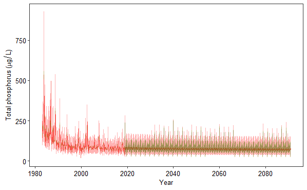

```r
# Plotting the results
plot_basics+
  geom_line(data = P1concL00.df, aes(x = date, y = `hyd50%`, color = "Median TP"))+
  geom_ribbon(data = P1concL00.df, aes(x = date, ymin = `hyd5%`, ymax = `hyd95%`), fill = "black", alpha = 0.3)+
  geom_ribbon(data = P1concL00.df, aes(x = date, ymin = `parhyd5%`, ymax = `parhyd95%`), fill = "green", alpha = 0.3)+
  geom_ribbon(data = P1concL00.df, aes(x = date, ymin = `all5%`, ymax = `all95%`), fill = "red", alpha = 0.3)+
  theme(legend.position = "none")+
  labs(x = "Year",
       y = expression(Total~phosphorus~"("*mu*g/L*")"))
```

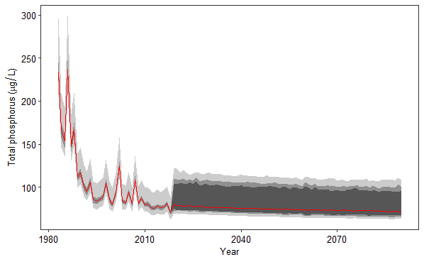

```r
# Plotting the results
## Smoothening the lines
plot_basics+
  geom_ribbon(data = P1concL00.df.ann, aes(x = Year, ymin = `hyd5%`, ymax = `hyd95%`), fill = "black", alpha = 0.4)+
  geom_ribbon(data = P1concL00.df.ann, aes(x = Year, ymin = `parhyd5%`, ymax = `parhyd95%`), fill = "black", alpha = 0.3)+
  geom_ribbon(data = P1concL00.df.ann, aes(x = Year, ymin = `all5%`, ymax = `all95%`), fill = "black", alpha = 0.2)+
  geom_line(data = P1concL00.df.ann, aes(x = Year, y = `hyd50%`, color = "Median TP"))+
  theme(legend.position = "none")+
  labs(x = "Year",
       y = expression(Total~phosphorus~"("*mu*g/L*")"))+
  scale_color_manual(values = c(`Median TP` = "red"))
```

## 9.3 Sediment P Concentration

Let us find the future projections for sediment TP across Jordan Lake with 90% prediction interval.

```r
# Sediment P concentrations
SL00.df <- PI_func(90, "Sconc")
SconcL00.df <- SL00.df[[1]]
SconcL00.df.ann <- SL00.df[[2]]
```

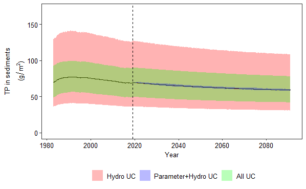

```r
# Plotting the results
plot_basics+
  geom_line(data = SconcL00.df, aes(x = date, y = `hyd50%`, color = "Median TP"))+
  geom_line(data = SconcL00.df, aes(x = date, y = `hyd_mean`, color = "Mean TP"))+
  geom_ribbon(data = SconcL00.df, aes(x = date, ymin = `all5%`, ymax = `all95%`, fill = "all"), alpha = 0.3)+
  geom_ribbon(data = SconcL00.df, aes(x = date, ymin = `parhyd5%`, ymax = `parhyd95%`, fill = "parhyd"), alpha = 0.3)+
  # geom_ribbon(data = Sconc.df[which(Sconc.df$date %in% date_scen),], aes(x = date, ymin = `hyd16%`, ymax = `hyd84%`, fill = "hyd"), alpha = 0.3)+
  geom_ribbon(data = SconcL00.df, aes(x = date, ymin = `hyd5%`, ymax = `hyd95%`, fill = "hyd"), alpha = 0.3)+
  theme(legend.position = "bottom",
        legend.text = element_text(size = 10))+
  labs(x = "Year",
       y = expression(atop(TP~"in"~sediments,"("*g/m^2*")")))+
  scale_fill_manual("",values = c(`hyd` = "blue",
                               `parhyd` = "green",
                               `all` = "red"),
                    labels = c("Hydro UC", "Parameter+Hydro UC", "All UC"),
                       guide = guide_legend(override.aes =
                                              list(alpha = c(0.1,0.1,0.1))))+
  scale_color_manual("", values = c(`Median TP` = "red",
                                    `Mean TP` = "black"),
                     labels = c(""),
                     guide = "none")+
  ylim(0,170)+
  geom_vline(xintercept = as.Date("2018-12-31", format = "%Y-%m-%d"), lty = 2)
```

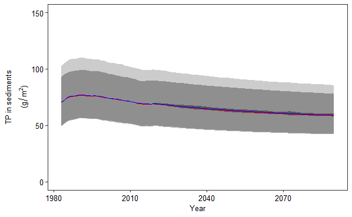

```r
# Plotting the results
plot_basics+
  geom_ribbon(data = SconcL00.df.ann, aes(x = Year, ymin = `hyd5%`, ymax = `hyd95%`), fill = "black", alpha = 0.4)+
  geom_ribbon(data = SconcL00.df.ann, aes(x = Year, ymin = `parhyd5%`, ymax = `parhyd95%`), fill = "black", alpha = 0.3)+
  geom_ribbon(data = SconcL00.df.ann, aes(x = Year, ymin = `all5%`, ymax = `all95%`), fill = "black", alpha = 0.2)+
  geom_line(data = SconcL00.df.ann, aes(x = Year, y = `parhyd50%`, color = "Median TP"))+
  geom_line(data = SconcL00.df.ann, aes(x = Year, y = `hyd_mean`, color = "Mean TP"))+
  theme(legend.position = "none")+
  labs(x = "Year",
       y = expression(atop(TP~"in"~sediments,"("*g/m^2*")")))+
  ylim(0,150)+
  scale_color_manual(values = c(`Median TP` = "red",
                                `Mean TP` = "blue"))
```

# 10 Percentage reduction

Let us now estimate the change in TP in water and sediments between 2019 and 2090.

```r
P1concL00.df.ann.R <- P1concL00.df.ann[which(P1concL00.df.ann$Year %in% c(2019, 2090)),]
SconcL00.df.ann.R <- SconcL00.df.ann[which(SconcL00.df.ann$Year %in% c(2019, 2090)),]

# Percentage reduction
## water column P
(P1concL00.df.ann.R[1,"hyd50%"] - P1concL00.df.ann.R[2,"hyd50%"])/P1concL00.df.ann.R[1,"hyd50%"]*100
```

```
[1] 10.59638
```

```r
## Sediment P
(SconcL00.df.ann.R[1, "hyd50%"] - SconcL00.df.ann.R[2, "hyd50%"])/SconcL00.df.ann.R[1,"hyd50%"]*100
```

```
[1] 14.95362
```

## 10.1 Decadal average

```r
# historical
P1concL00.df.dec.R <- P1concL00.df.ann[which(P1concL00.df.ann$Year %in% c(2019:2028, 2081:2090)),] %>% mutate(decade = rep(c(1,2), each = 10)) %>% group_by(decade) %>%
  summarise(Pconc = mean(`hyd50%`))

SconcL00.df.dec.R <- SconcL00.df.ann[which(SconcL00.df.ann$Year %in% c(2019:2028, 2081:2090)),] %>% mutate(decade = rep(c(1,2), each = 10)) %>% group_by(decade) %>%
  summarise(Sconc = mean(`hyd50%`))


# Percentage reduction
## water column P
(P1concL00.df.dec.R[1,"Pconc"] - P1concL00.df.dec.R[2,"Pconc"])/P1concL00.df.dec.R[1,"Pconc"]*100
```

| Pconc |
| --- |
| 7.749162 |

```r
## Sediment P
(SconcL00.df.dec.R[1, "Sconc"] - SconcL00.df.dec.R[2, "Sconc"])/SconcL00.df.dec.R[1,"Sconc"]*100
```

| Sconc |
| --- |
| 12.97714 |

## 10.2 Sediment P release

```r
# Sediment P release
SPresL00.df <- PI_func(90, "Sres")
SresL00.df <- SPresL00.df[[1]]

## Adding seasons
SresL00.df <- SresL00.df %>% mutate(Season = Season(date))
```

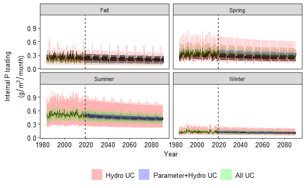

```r
# Plotting the results
plot_basics+
  geom_line(data = SresL00.df, aes(x = date, y = `hyd50%`, color = "Median TP"))+
  geom_line(data = SresL00.df, aes(x = date, y = `hyd_mean`, color = "Mean TP"))+
  geom_ribbon(data = SresL00.df, aes(x = date, ymin = `all5%`, ymax = `all95%`, fill = "all"), alpha = 0.3)+
  geom_ribbon(data = SresL00.df, aes(x = date, ymin = `parhyd5%`, ymax = `parhyd95%`, fill = "parhyd"), alpha = 0.3)+
  # # geom_ribbon(data = Sres.df[which(Sconc.df$date %in% date_scen),], aes(x = date, ymin = `hyd16%`, ymax = `hyd84%`, fill = "hyd"), alpha = 0.3)+
  geom_ribbon(data = SresL00.df, aes(x = date, ymin = `hyd5%`, ymax = `hyd95%`, fill = "hyd"), alpha = 0.3)+
  facet_wrap(vars(Season))+
  theme(legend.position = "bottom",
        legend.text = element_text(size = 10))+
  labs(x = "Year",
       y = expression(atop(Internal~P~loading,"("*g/m^2/month*")")))+
  scale_fill_manual("",values = c(`hyd` = "blue",
                               `parhyd` = "green",
                               `all` = "red"),
                    labels = c("Hydro UC", "Parameter+Hydro UC", "All UC"),
                       guide = guide_legend(override.aes =
                                              list(alpha = c(0.1,0.1,0.1))))+
  scale_color_manual("", values = c(`Median TP` = "red",
                                    `Mean TP` = "black"),
                     labels = c(""),
                     guide = "none")+
  # ylim(0,200)+
  geom_vline(xintercept = as.Date("2018-12-31", format = "%Y-%m-%d"), lty = 2)
```

# 11 Saving the workspace

```r
# Saving the file (last saved on 04/30/2023 10:00 PM) with mean central value
# save.image("RWorkSpaces/JLPMv016p010_1.RData")
```

```r
# Start timer
End_timer10 <- Sys.time()

# Total time taken to run the entire notebook
Tot_time10 <- End_timer10 - Start_timer10
Tot_time10
```

```
Time difference of 12.18309 hours
```